# A comparison of the behaviour of female and male wild boars after an encounter with the Wildschweinschreck

Sarah Helbling

## Introduction

Wild boar ( *Sus scrofa* L.) populations in wide parts of Europe, including Switzerland, have sharply increased in the past decades ( *Goulding, 2003; Maissei et al., 2015*). The main reasons for this increase is the high availability of food in combination with the high reproductive rate of wild boars ( *Geisser, 2005*) . Wild boars often feed in maize and wheat fields ( *Henning, 1998*) causing a lot of damage to the farmers. There are several methods to keep wild boars away from the field, e.g., increasing hunting pressure, electrical fences and acoustic deterrence ( *Breton, 1994; Mazzoni della Stella et al., 1995; Suter & Eyholzer, 2010;Vassant, 1997*).

In a study conducted between 2013 and 2017, all the above mentioned methods were tested and compared, to determine how agricultural land and nature reserves can best be protected from damage by wild boars ( *Suter, Stoller, Sigrist, 2018*). The authors concluded, that acoustic deterrence is especially suitable directly after the sowing of crops and shortly before maize and wheat are ripe (german: Milchreife). In combination with a hightend hunting pressure, acoustic deterrence is even more effective, while electrical fences only keep wild boars away from field when built and maintained well.

The study mainly focused on a comparison of the deterrence methods, but ignored the social structure of wild boars. The social structure of wild boars might have an influence on the behaviour of female versus male wild boars, insofar as that adult males mostly live isolated, while females and young boars live together in herds ( *Bon et al., 1986; Rossell et al., 2004*). Considering this social structure, this project aims to compare female and male wild boars and their behaviour after an encounter with an acoustic deterrence.

## Material and Methods

The data for this project was collected in the context of the [Evalutation eiens akustischen Wildschwein-Vergrämungssystems](https://www.zhaw.ch/de/forschung/forschungsdatenbank/projektdetail/projektid/842/). Further information about this study can be found in the [final report](https://www.zhaw.ch/storage/hochschule/medien/bildmaterial/Schlussbericht_Wildschweinschreck.pdf) (language: German) of the study and the [R package](https://computationalmovementanalysis.github.io/ComputationalMovementAnalysisData/index.html) of the data.

In the years 2013-2017 46 fields and 39 wild boars were studied. The acoustic deterrence system fundamentally consisted of two loudspeakers that played species-specific warning noises of different wild boar individuals. Non-species-specific warning noises such as human steps, human voices and sounds of gun shots were added to further deter wild boars ( *Suter, Stoller & Sigrist, 2018*).

### Material

For the analysis the following data sets of the R package Computational Movement Analysis Data were used: -wildboar data: -wildschwein_BE; -wildschwein_metadata. -wildschwein schreck data: -schreck_agenda; -schreck_locations.

### Methods

In order to determine the encounter of a wild boar with a acoustic deterrence location (detloc), all wild boar GPS points within a 500 m radius of the detloc were selected, as well as all points within a time window of one hour before and six hours after the initial encounter.

The movement parameter “distance” or steplength was created using the Euclidean Distance between points, while speed is the distance divided by the timelag in between location fixes. As the sampling regime included a location fix every 15 min. between 17:00 and 05:00, and a location fix every three hours (08:00, 11:00, 14:00, 17:00) during the day.

Bounding box of all points of f/m_encounters xmin ymin xmax ymax 2’568’440 1’202’900 2’574’921 1’207’596

The descriptions of the ground cover (swissTLM3D Bodenbedeckung) were taken from the **Objektkatalog** ( **swisstopo, 2022**).

## Results

### Comparison speeds of female and male wild boars within 1h of the encounter

H0: The difference in the speeds of female and male wild boars have no systematic reason but occurred at random. H1: The difference in the speeds of female and male wild boars have a systematic reason.

```
##
##  Shapiro-Wilk normality test
##
## data:  f_1h$speed
## W = 0.79185, p-value < 2.2e-16
```

```
##
##  Shapiro-Wilk normality test
##
## data:  m_1h$speed
## W = 0.89311, p-value = 1.012e-05
```

```
##
##  Wilcoxon rank sum test with continuity correction
##
## data:  f_1h$speed and m_1h$speed
## W = 11234, p-value = 0.03375
## alternative hypothesis: true location shift is not equal to 0
```

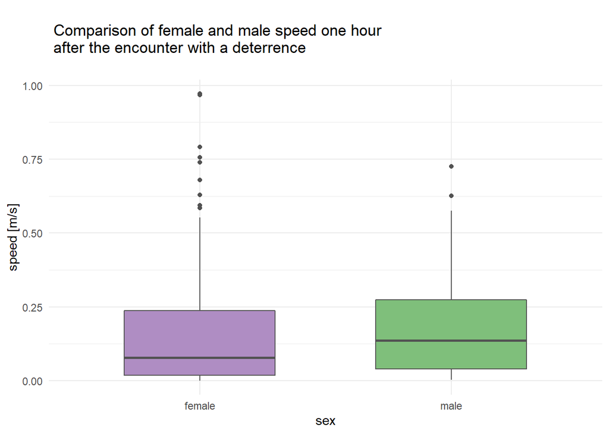

```
##
##  Kruskal-Wallis rank sum test
##
## data:  speed by modus
## Kruskal-Wallis chi-squared = 7.5315, df = 2, p-value = 0.02315
```

```
##
##  Kruskal-Wallis rank sum test
##
## data:  speed by lautstaerke
## Kruskal-Wallis chi-squared = 20.75, df = 3, p-value = 0.0001186
```

```
##
##  Kruskal-Wallis rank sum test
##
## data:  speed by modus
## Kruskal-Wallis chi-squared = 0.015939, df = 1, p-value = 0.8995
```

```
##
##  Kruskal-Wallis rank sum test
##
## data:  speed by lautstaerke
## Kruskal-Wallis chi-squared = 1.5603, df = 1, p-value = 0.2116
```

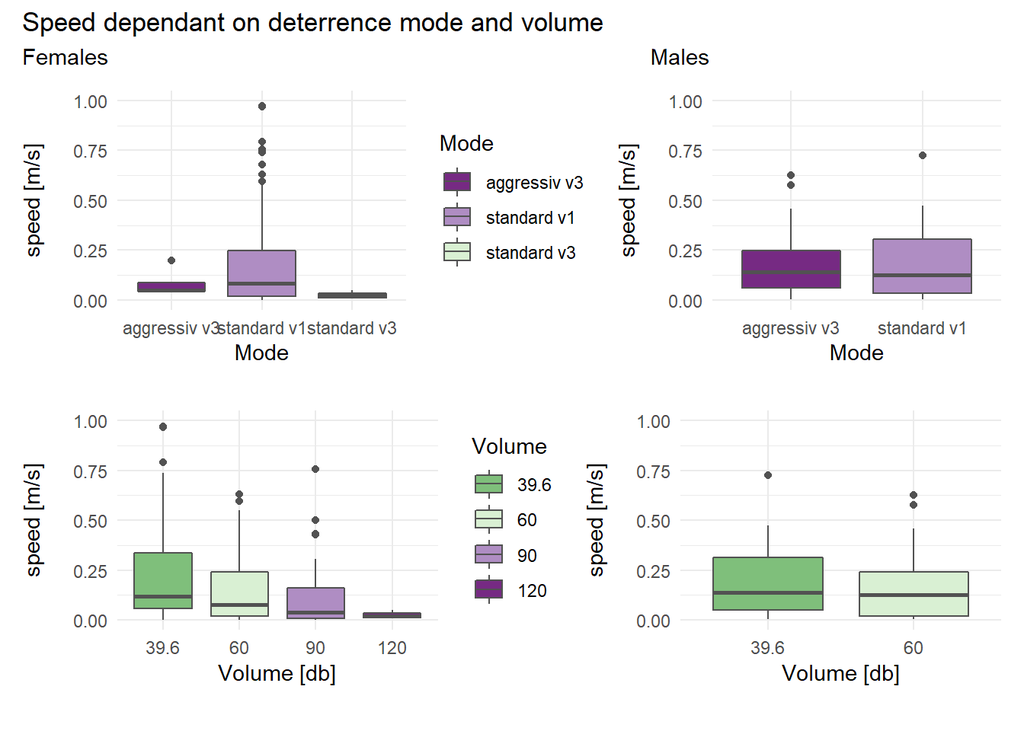

Comparison of distance 1h after encounter

```
##
##  Shapiro-Wilk normality test
##
## data:  f_1h_dist$dist
## W = 0.87959, p-value = 6.208e-07
```

```
##
##  Shapiro-Wilk normality test
##
## data:  m_1h_dist$dist
## W = 0.91479, p-value = 0.09068
```

```
##
##  Wilcoxon rank sum test with continuity correction
##
## data:  f_1h_dist$dist and m_1h_dist$dist
## W = 690, p-value = 0.2111
## alternative hypothesis: true location shift is not equal to 0
```

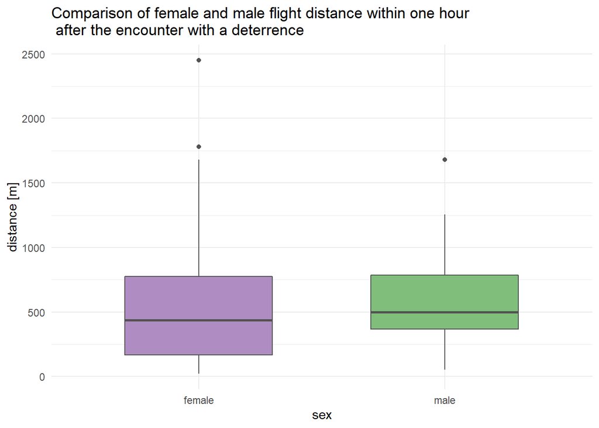

Does volume or modus have an influence on distance 1h after encounter

```
##
##  Kruskal-Wallis rank sum test
##
## data:  dist by modus
## Kruskal-Wallis chi-squared = 7.1233, df = 2, p-value = 0.02839
```

```
##
##  Kruskal-Wallis rank sum test
##
## data:  dist by lautstaerke
## Kruskal-Wallis chi-squared = 7.4685, df = 3, p-value = 0.05837
```

```
##
##  Kruskal-Wallis rank sum test
##
## data:  dist by modus
## Kruskal-Wallis chi-squared = 0.10909, df = 1, p-value = 0.7412
```

```
##
##  Kruskal-Wallis rank sum test
##
## data:  dist by lautstaerke
## Kruskal-Wallis chi-squared = 1.2071, df = 1, p-value = 0.2719
```

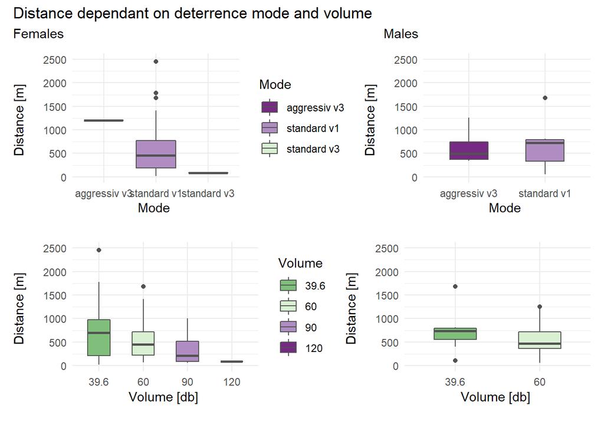

Comparing distances of each hour (1-6) after the encounter

```
##
##  Kruskal-Wallis rank sum test
##
## data:  dist by encounter
## Kruskal-Wallis chi-squared = 53.547, df = 5, p-value = 2.597e-10
```

```
##
##  Kruskal-Wallis rank sum test
##
## data:  dist by encounter
## Kruskal-Wallis chi-squared = 11.086, df = 5, p-value = 0.04971
```

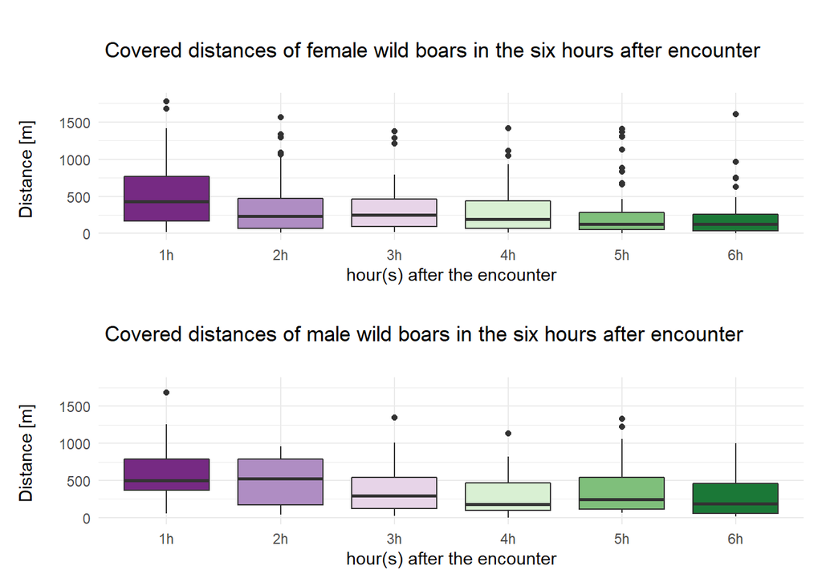

Now, which wild boars came back to a field with a deterrence several times?

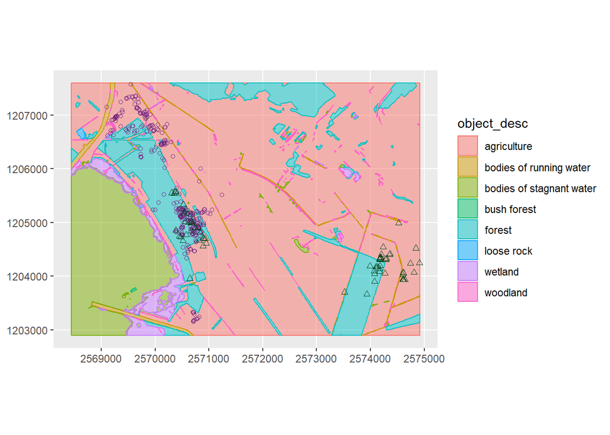

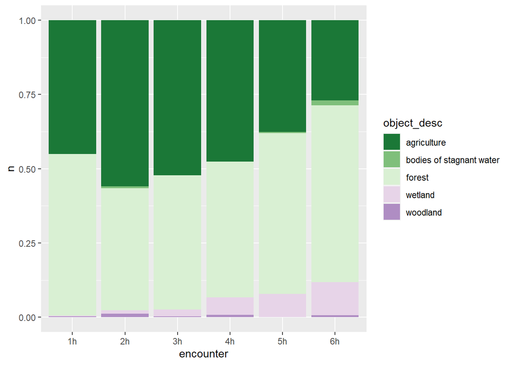

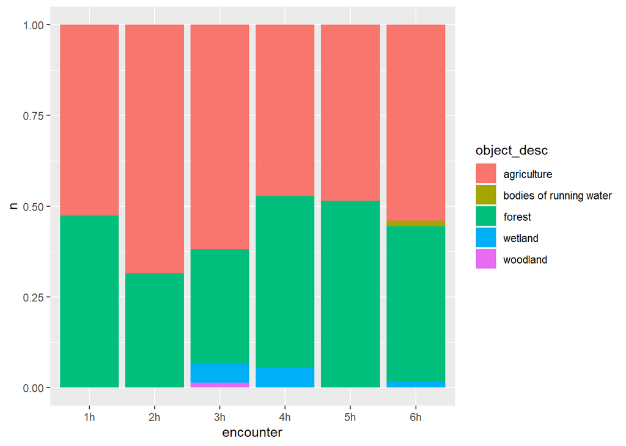

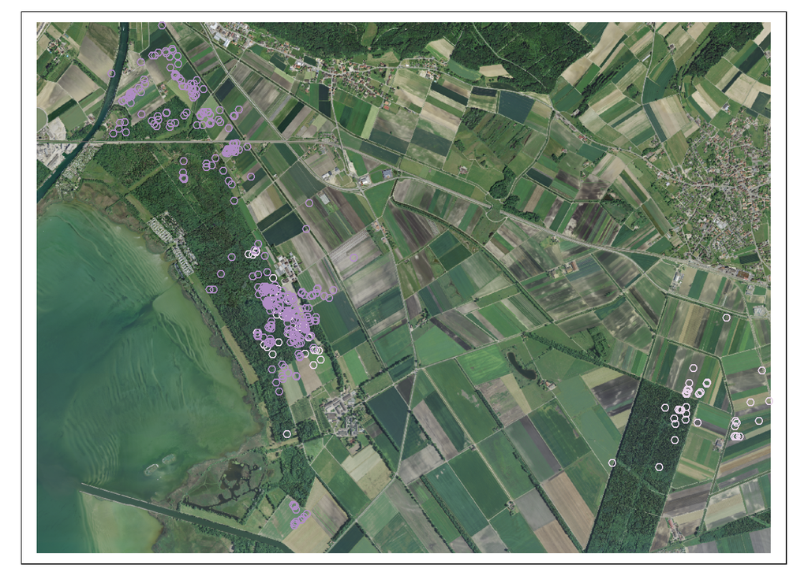